# Tosca - Die Hamburgische Staatsoper

[Die Hamburgische Staatsoper](https://www.die-hamburgische-staatsoper.de/de)

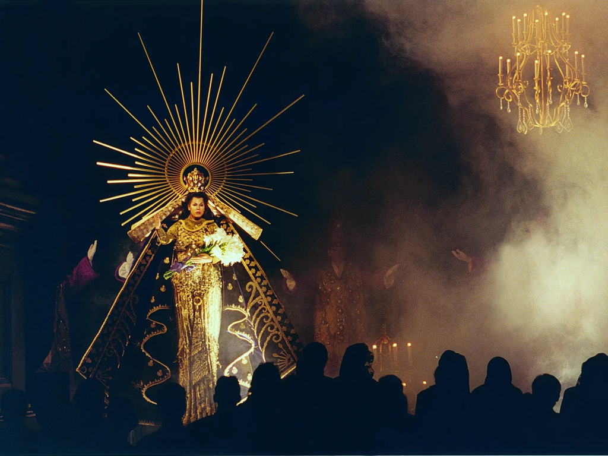

Brinkhoff / Mögenburg

[Programm](https://www.die-hamburgische-staatsoper.de/de/programm/) → Oper

# Tosca

Giacomo Puccini

Inszenierung von 2000

- Fr 7.11. 19:30 Tickets
- Fr 14.11. 19:30 Tickets
- Sa 29.11. 19:30 Tickets
- Di 23.12. 19:30 Tickets
- Zum letzten Mal in dieser Spielzeit

  Do 1.1. 19:30 Tickets

Für die Kunst und für die Liebe habe sie gelebt, singt Floria Tosca. Von den größten Sänger:innen ihrer Zeit interpretiert, reflektiert Puccinis im Januar 1900 uraufgeführtes Melodramma – so inhaltlich schockierend wie melodisch wunderschön – künstlerische Konflikte in totalitären Regimen genauso wie das Verhältnis von Kirche und Staat. Themen, die Robert Carsens Inszenierung in all ihrer Vielschichtigkeit auf die Bühne bringt.

## „Bravi tutti!“ Das Opernmagazin

Melodramma in drei Akten  
Komposition: Giacomo Puccini  
Libretto: Giuseppe Giacosa und Luigi Illica nach dem gleichnamigen Schauspiel von Victorien Sardou

- 1900 14. Januar, Uraufführung am Teatro dell'Opera in Rom
- 2000 15. Oktober, Premiere dieser Inszenierung an der Hamburgischen Staatsoper
- 2026 Vortrag: Am 1. Januar 2026, 18:45 findet im Vorderhaus der Hamburgischen Staatsoper der Vortrag „Fetisch Stimme: Die berühmtesten Toscen“ von Prof. Michael Stegemann statt.

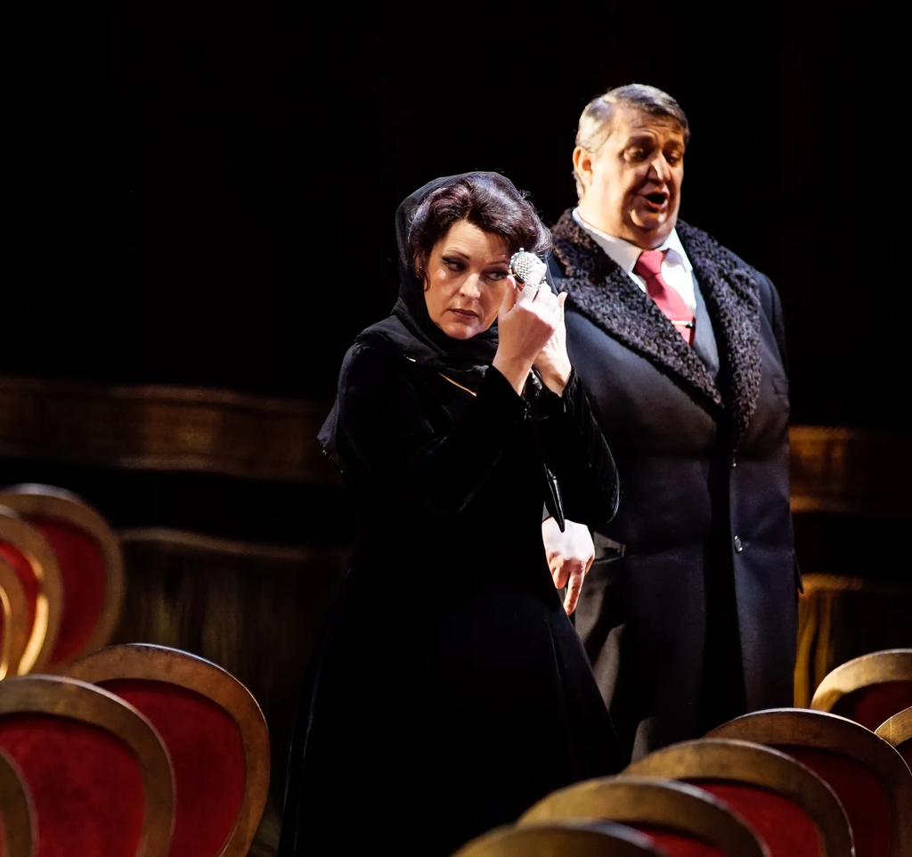

- **© ×**

  Arno Declair

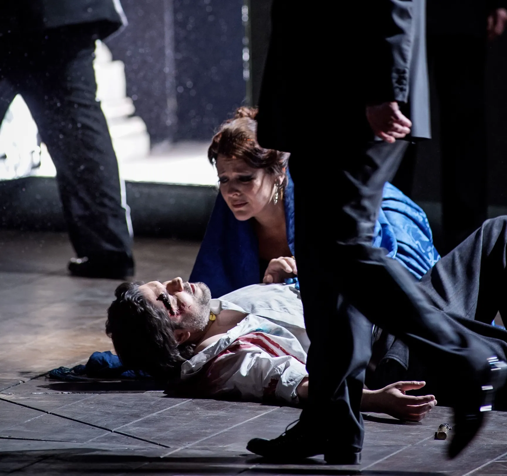

- **© ×**

  Arno Declair

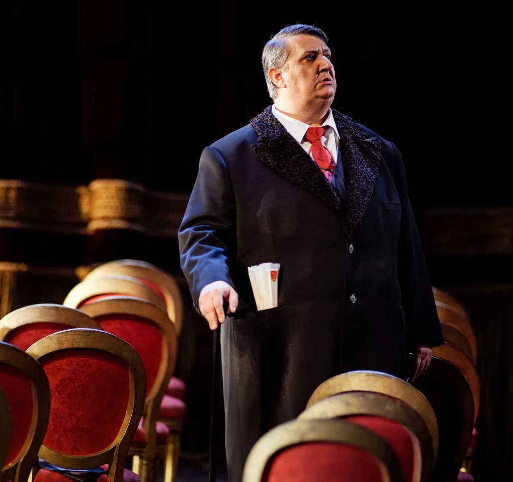

- **© ×**

  Arno Declair

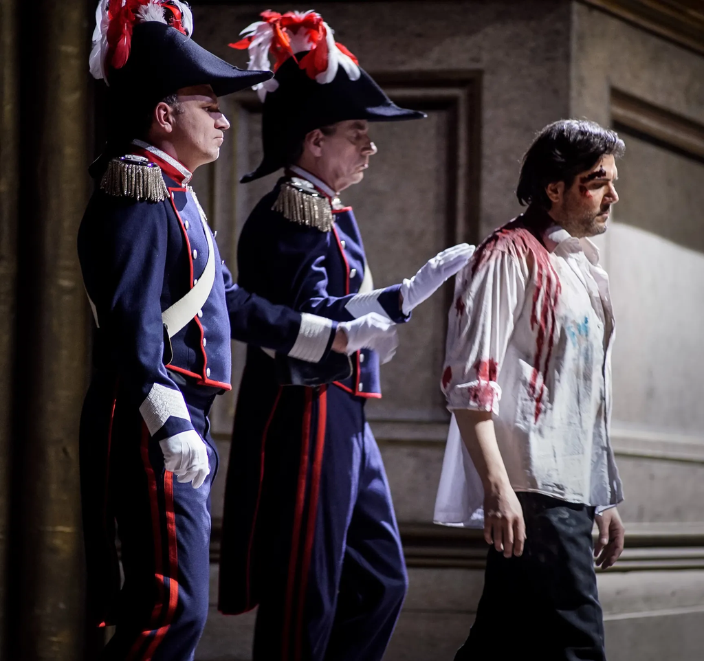

- **© ×**

  Arno Declair

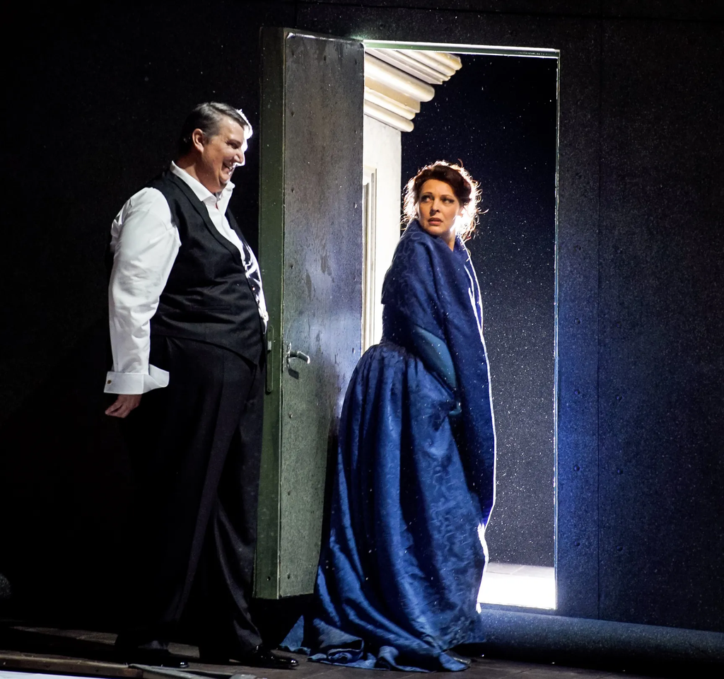

- **© ×**

  Arno Declair

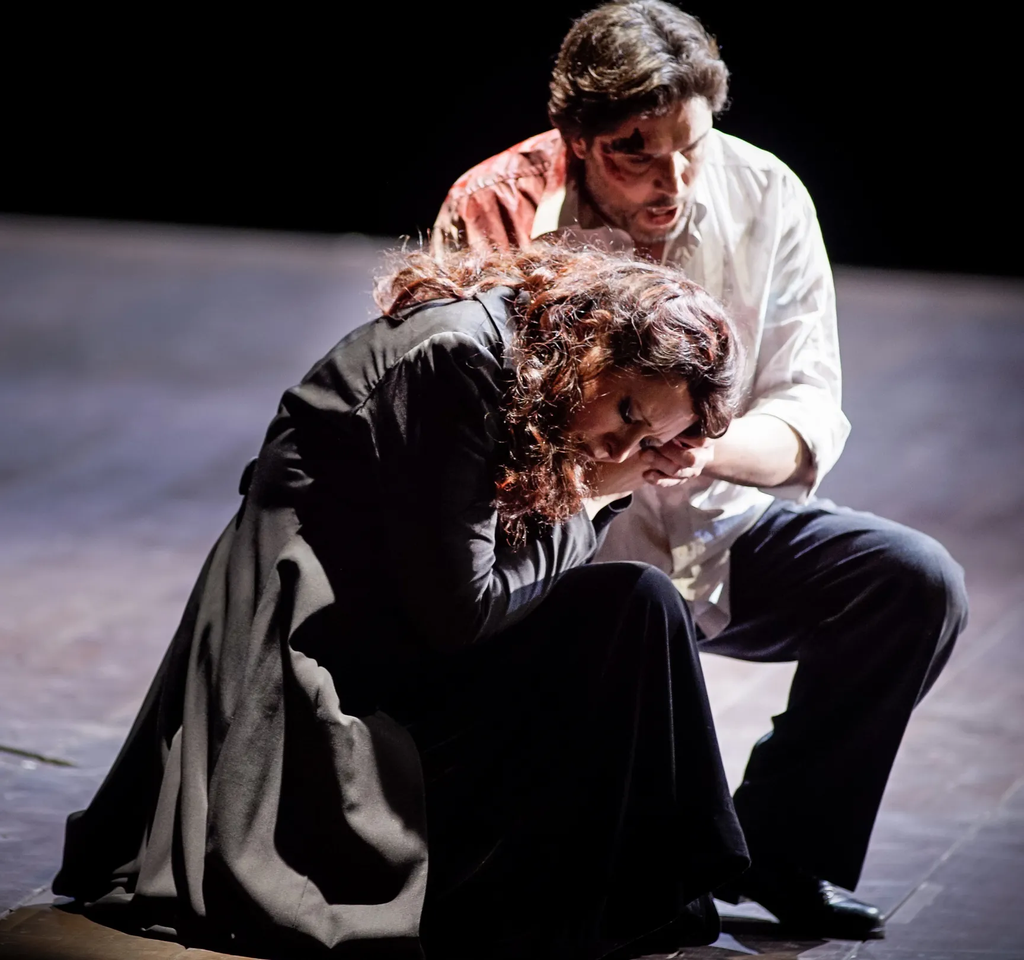

- **© ×**

  Arno Declair

## Besetzung

- Musikalische Leitung

  [Giampaolo Bisanti](https://www.die-hamburgische-staatsoper.de/de/personen/39913085-giampaolo-bisanti)
- Inszenierung

  [Robert Carsen](https://www.die-hamburgische-staatsoper.de/de/personen/1351-robert-carsen)
- Bühne

  [Anthony Ward](https://www.die-hamburgische-staatsoper.de/de/personen/1404-anthony-ward)
- Kostüme

  [Anthony Ward](https://www.die-hamburgische-staatsoper.de/de/personen/1404-anthony-ward)
- Licht

  Davy Cunningham
- Chor

  [Alice Meregaglia](https://www.die-hamburgische-staatsoper.de/de/personen/39915784-alice-meregaglia)
- Dramaturgie

  [Ian Burton](https://www.die-hamburgische-staatsoper.de/de/personen/1344-ian-burton)
- Floria Tosca

  [Ewa Vesin](https://www.die-hamburgische-staatsoper.de/de/personen/39915526-ewa-vesin)
  - 7.11.25 /
  - 14.11.25

  [Ewa Płonka](https://www.die-hamburgische-staatsoper.de/de/personen/39915019-ewa-plonka)
  - 29.11.25 /
  - 23.12.25 /
  - 1.1.26
- Mario Cavaradossi

  [Young Woo Kim](https://www.die-hamburgische-staatsoper.de/de/personen/39914958-young-woo-kim)
  - 7.11.25 /
  - 14.11.25

  [Joseph Calleja](https://www.die-hamburgische-staatsoper.de/de/personen/5039-joseph-calleja)
  - 29.11.25 /
  - 23.12.25 /
  - 1.1.26
- Baron Scarpia

  [Gabriele Viviani](https://www.die-hamburgische-staatsoper.de/de/personen/5175-gabriele-viviani)
- Cesare Angelotti

  [Tigran Martirossian](https://www.die-hamburgische-staatsoper.de/de/personen/4056-tigran-martirossian)
- Sagrestano

  [William Desbiens](https://www.die-hamburgische-staatsoper.de/de/personen/39915891-william-desbiens)
- Spoletta

  [Peter Galliard](https://www.die-hamburgische-staatsoper.de/de/personen/568-peter-galliard)
- Sciarrone

  [Keith Klein](https://www.die-hamburgische-staatsoper.de/de/personen/39915892-keith-klein)
- Un Pastore

  [Solist des Hamburger Knabenchores](https://www.die-hamburgische-staatsoper.de/de/personen/2147485722-solist-des-hamburger-knabenchores)
- [Alsterspatzen – Kinder- und Jugendchor der Hamburgischen Staatsoper](https://www.die-hamburgische-staatsoper.de/de/personen/4084-alsterspatzen-kinder-und-jugendchor-der-hamburgischen-staatsoper)
- [Chor der Hamburgischen Staatsoper](https://www.die-hamburgische-staatsoper.de/de/personen/5469-chor-der-hamburgischen-staatsoper)
- [Philharmonisches Staatsorchester Hamburg](https://www.die-hamburgische-staatsoper.de/de/personen/1929-philharmonisches-staatsorchester-hamburg)

## Das Stück

- Spielstätte Staatsoper, Großes Haus
- Dauer 160 Min
- Pause Eine Pause von ca. 25 Minuten nach dem ersten Akt (nach etwa 50 Minuten)
- Altersempfehlung Ab 13 Jahren / Klasse 8
- Sprache In italienischer Sprache mit deutschen und englischen Übertiteln

„Vissi d’arte, vissi d’amore“, singt Floria Tosca im zweiten Akt von Giacomo Puccinis Oper. Für die Kunst und für die Liebe habe sie gelebt. Heftig ist dieses Werk, schockierend. Bringt Folter, Suizid und Hinrichtung auf die Bühne, ästhetisiert diese zugleich und verpackt sie in die wunderschönsten Melodien. Interpretiert seit der Uraufführung 1900 von den größten Sänger:innen ihrer Zeit. Einen weiten thematischen Bogen zeichnet das Stück, reflektiert Fragen zu möglichen Konflikten von Künstler:innen in totalitären Regimen genauso wie das Verhältnis von Kirche und Staat, spürt dem Kern von Eifersucht nach, ein Gefühl, das Tosca zutiefst umtreibt. Themen, die Robert Carsens Inszenierung in all ihrer Vielschichtigkeit auf die Bühne bringt.  
Uraufgeführt wurde das Melodramma am 14. Januar 1900 am Teatro dell’Opera in Rom. Die Hamburger Inszenierung feierte am 15. Oktober 2000 Premiere.

Rahmenprogramm

Mit FRAMING the REPERTOIRE beleuchten wir vergangene Inszenierungen als eigenständige Kunstform.

[Mehr dazu](https://www.die-hamburgische-staatsoper.de/de/ueberuns/oper/framing-the-repertoire)

- GUIDANCE: Diskutieren Sie mit jungen Expert:innen über Werk, Inszenierung und Relevanz – vor, während und nach jeder Vorstellung in den Foyers
- Vortrag: Am 1. Januar 2026, 18:45 findet im Vorderhaus der Hamburgischen Staatsoper der Vortrag „Fetisch Stimme: Die berühmtesten Toscen“ von Prof. Michael Stegemann statt.

Über die Inszenierung

von Dr. Judith Wiemers

„Vissi d’arte“ – „Ich lebte für die Kunst“ singt Floria Tosca im zweiten Akt von Giacomo Puccinis Oper – seit der Uraufführung im Jahr 1900 eine der berühmtesten Arien des Repertoires überhaupt. Der für seine psychologisch feinsinnigen Arbeiten gerühmte kanadische Regisseur Robert Carsen nimmt sie zum Ausgangspunkt seiner Hamburger Inszenierung aus dem Jahr 2000, in der die Rolle der Titelfigur als Künstlerin in den Mittelpunkt der szenischen Interpretation rückt. Als gefeierte Diva steht Floria Tosca immer auf der Bühne: Ihre Stimme und ihr Körper werden vom Publikum fetischisiert, ihr Privatleben der Öffentlichkeit preisgegeben. Hinter dem eisernen Sicherheitsvorhang eines Theaters wird sie zum Opfer patriarchaler Machtverhältnisse, belauert von Scarpia; ein Mann, der sie als Ikone gleichermaßen bewundert, begehrt und beherrscht.

In diesem Werk des Verismo, das Themen wie sexuelle Gewalt, Suizid und Hinrichtung schonungslos und gleichzeitig ästhetisiert auf die Bühne bringt, überträgt Carsen den unerbittlichen Blick Scarpias auf das Publikum. Von einem einzelnen Scheinwerfer erfasst, wird Tosca ausgeleuchtet, muss sich vor ihrem Widersacher – und unweigerlich vor uns – buchstäblich nackt machen und zu einem Ideal modellieren lassen. Zufluchtsort ist ihr ebenjene Arie: eine Welt der sentimentalen Fantasie und Gauklerei. In Toscas Bekenntnis zur Kunst verbindet sich Puccinis Klangschönheit mit einem Moment existenziellen Leids, dem wir voyeuristisch beiwohnen und den wir doch eingeladen sind, zu genießen. Robert Carsen, der sich seit den 1980er Jahren mit Inszenierungen in ganz Europa und darüber hinaus als einer der gefragtesten Regisseure seiner Generation etablierte, reflektiert hier nicht nur die Rolle des Theaterpublikums, sondern auch die Verantwortung des Regisseurs, der seine Künstler:innen leitet, formt – und ausstellt. Ebenso wie er den Zwiespalt einer Künstlerpersönlichkeit zwischen Hingabe und Aufopferung aufschlüsselt und emotional erfahrbar macht, richtet er einen kritischen Fokus auf die hierarchischen Strukturen von großen institutionellen Einrichtungen, wie es die Kirche, aber auch das Theater ist.

Die Gewalt gegen Tosca, die hier vor allem eine psychologische ist, verbildlichen Carsen und der Ausstatter Anthony Ward mit reduzierten Mitteln und pointiert eingesetzter Lichtregie auch in ihrem karg-kalten Theaterraum, in dem einzelne Requisiten – wie der im Applaus zugeworfene Blumenstrauß – gleichsam zu religiös aufgeladenen Reliquien werden. Eine Selbstbehauptung oder gar -befreiung der Künstlerin scheint hier kaum denkbar. Gefangen im Korsett ihres Bühnenkostüms, auf den Brettern, die ihr die Welt bedeuten, ist Toscas einziger Ausweg aus ihrer Rolle ein ungewisser: ins dunkle Nichts abseits des so lockenden wie blendenden Rampenlichts.

- - Musikalische Leitung [Giampaolo Bisanti](https://www.die-hamburgische-staatsoper.de/de/personen/39913085-giampaolo-bisanti)

  [Wochentags-Abo (Fr1)](https://www.die-hamburgische-staatsoper.de/de/service/abos#wochentags-abos) · 7€ 15€ 23€ 41€ 62€ 77€ 91€ 103€ 115€ 129€

  [Details](https://www.die-hamburgische-staatsoper.de/de/programm/oper/136-tosca)
- - Musikalische Leitung [Giampaolo Bisanti](https://www.die-hamburgische-staatsoper.de/de/personen/39913085-giampaolo-bisanti)

  [Wochentags-Abo (Fr2)](https://www.die-hamburgische-staatsoper.de/de/service/abos#wochentags-abos) · 7€ 15€ 23€ 41€ 62€ 77€ 91€ 103€ 115€ 129€

  [Details](https://www.die-hamburgische-staatsoper.de/de/programm/oper/136-tosca)
- - Musikalische Leitung [Giampaolo Bisanti](https://www.die-hamburgische-staatsoper.de/de/personen/39913085-giampaolo-bisanti)

  7€ 15€ 24€ 43€ 67€ 82€ 96€ 109€ 122€ 137€

  [Details](https://www.die-hamburgische-staatsoper.de/de/programm/oper/136-tosca)
- - Musikalische Leitung [Giampaolo Bisanti](https://www.die-hamburgische-staatsoper.de/de/personen/39913085-giampaolo-bisanti)

  7€ 13€ 21€ 38€ 56€ 71€ 83€ 94€ 105€ 119€

  [Details](https://www.die-hamburgische-staatsoper.de/de/programm/oper/136-tosca)
- - Musikalische Leitung [Giampaolo Bisanti](https://www.die-hamburgische-staatsoper.de/de/personen/39913085-giampaolo-bisanti)

  7€ 15€ 23€ 41€ 62€ 77€ 91€ 103€ 115€ 129€

  [Details](https://www.die-hamburgische-staatsoper.de/de/programm/oper/136-tosca)

[interactive chart not shown]